# Création de cartes choroplèthes avec ggplot2

# Objectifs d’apprentissage

Dans cette leçon, vous apprendrez principalement à utiliser le package ggplot2, en particulier les fonctions `ggplot()` et `geom_sf()`, pour créer de belles cartes choroplèthes.

Plus spécifiquement, vous apprendrez comment :

1. Faire correspondre des données brutes à des polygones
- Obtenir des limites/polynômes
- Obtenir des données liées aux maladies
- Joindre par niveau administratif
2. Appliquer une échelle de couleurs pour les variables continues et discrètes
- Continues
- Discrètes
3. Appliquer Facet Wrap et Grid
- Créer de petits multiples et utiliser `facet_wrap()`
- Créer de petits multiples et utiliser `facet_grid()`

# 1 Introduction

Une carte choroplèthe est une carte thématique dans laquelle les régions géographiques sont ombrées ou hachurées en proportion de la valeur d’une variable représentée. Cette variable peut être un indicateur épidémiologique tel que la prévalence des maladies ou le taux de mortalité. Les cartes choroplèthes sont particulièrement utiles pour visualiser les schémas spatiaux et les variations à travers différentes régions.

Les composantes essentielles d’une carte choroplèthe comprennent :

**Régions géographiques** : Il s’agit des zones qui seront représentées sur la carte, telles que les pays, les États, les districts ou toute autre division géographique.

**Valeurs des données** : Ce sont les valeurs associées à chaque région géographique qui seront représentées sur la carte, y compris la densité de population, la prévalence, l’incidence, le taux de mortalité, etc.

**Échelle de couleurs** : Il s’agit de la gamme de couleurs utilisée pour représenter les différentes valeurs des données. Généralement, on utilise un dégradé de couleurs, les couleurs plus claires représentant des valeurs plus faibles et les couleurs plus foncées représentant des valeurs plus élevées.

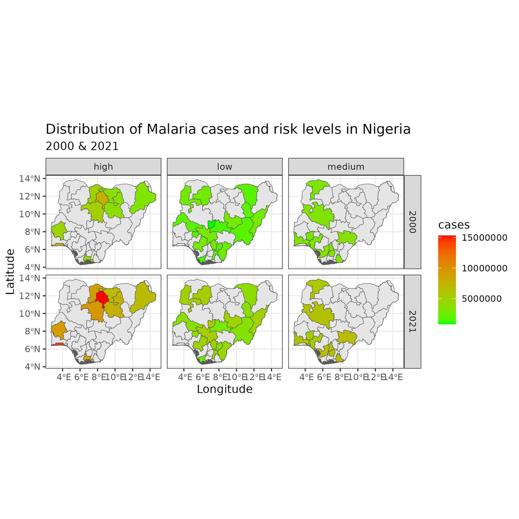

Les cartes choroplèthes présentent plusieurs avantages notables :

- **Clarté visuelle** : Elles fournissent une représentation visuelle claire de la distribution spatiale des données, ce qui facilite l’identification des schémas et des tendances.
- **Facilité de compréhension** : Elles sont intuitives et faciles à comprendre, même pour les personnes sans connaissance approfondie dans le domaine.
- **Polyvalence** : Elles peuvent être utilisées pour représenter une grande variété de données, ce qui les rend adaptées à diverses applications.

Cependant, il existe également des limitations importantes à prendre en compte :

- **Sensibilité aux données** : L’apparence de la carte peut être considérablement affectée par le choix de la classification des données et de l’échelle de couleurs.
- **Biais de la taille géographique** : Les régions plus grandes peuvent sembler plus prédominantes sur la carte, ce qui entraîne un biais visuel.

Dans la section suivante, vous apprendrez comment créer une carte choroplèthe à l’aide du package {ggplot2} dans R.

## 1.1 Packages

Cet extrait de code montre le chargement des packages nécessaires pour les analyses. Dans ce guide, nous mettons l’accent sur `p_load()` du package `pacman`, qui installe le package si nécessaire et le charge pour l’utilisation. Vous pouvez également charger des packages installés avec `library()` de base R. Consultez la page sur les bases de R pour plus d’informations sur la gestion des packages en R.

```r
# Charger les packages
pacman::p_load(tidyverse,
               here,
               sf)

# Désactiver la notation scientifique
options(scipen=10000)
```

# 2 Préparation des données

Avant de créer une carte choroplèthe, il est essentiel de préparer les données. Les données doivent contenir les régions géographiques et les valeurs que vous souhaitez visualiser.

Dans cette section, vous passerez par le processus de préparation des données, qui comprend les étapes suivantes :

1. **Importation des données polygonales** : Il s’agit des données géographiques qui contiennent les limites de chaque région que vous souhaitez inclure dans votre carte.
2. **Importation des données attributaires** : Il s’agit des données contenant les valeurs que vous souhaitez visualiser sur la carte, telles que la prévalence des maladies, la densité de la population, etc.
3. **Joindre les données polygonales et attributaires** : Cette étape consiste à fusionner les données polygonales avec les données attributaires en fonction d’un identifiant commun, tel que le niveau administratif ou le nom de la région. Cela créera un seul ensemble de données contenant à la fois les limites géographiques et les valeurs de données correspondantes.

Maintenant, passons en revue chaque étape en détail !

## 2.1 Étape 1 : Importation des données polygonales

Les polygones sont des formes fermées avec trois côtés ou plus. Dans les données spatiales, les polygones sont utilisés pour représenter des zones telles que les limites d’une ville, d’un lac ou d’un type d’utilisation des terres. Ils sont essentiels dans les systèmes d’information géographique (SIG) pour des tâches telles que la cartographie, l’analyse spatiale et la classification de l’occupation des terres.

Les fichiers shapefile sont un format courant pour stocker des données spatiales. Ils se composent d’au moins trois fichiers avec les extensions .shp (forme), .shx (index) et .dbf (données attributaires).

En R, vous pouvez charger des fichiers shapefile à l’aide du package `sf`. Dans notre leçon d’aujourd’hui, nous travaillerons avec des données sur le paludisme provenant de la revue épidémiologique du Nigéria (2022).

```r
# Lecture du fichier shapefile
nga_adm1 <-
  sf::st_read(here::here("data/raw/NGA_adm_shapefile/NGA_adm1.shp"))
```

Les éléments importants de n’importe quelle couche ggplot sont les associations esthétiques `aes(x, y, …)` qui indiquent à ggplot où placer les objets du graphique.

Nous pouvons imaginer une carte comme un graphique avec toutes les caractéristiques associées à un axe x et un axe y. Tous les types de géométrie (`geom_`) dans ggplot ont une sorte d’association esthétique, et celles-ci peuvent être déclarées au niveau du graphique, par exemple, `ggplot(data, aes(x = variable1, y = variable2))`, ou au niveau de la couche individuelle, par exemple, `geom_point(aes(color = variable3))`.

Ci-dessous, vous pouvez voir que `geom_sf()` est utilisé pour tracer les limites des différents États du Nigéria. De manière similaire, différentes couches peuvent être ajoutées par-dessus.

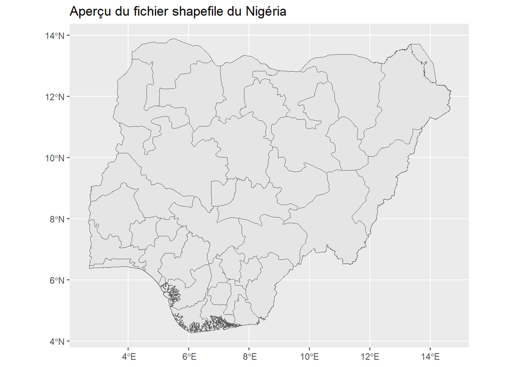

```r
ggplot()+
  geom_sf(data = nga_adm1)+
  labs(title = "Aperçu du fichier shapefile du Nigéria")
```

Ici, nous lisons d’abord le fichier shapefile du Nigéria en utilisant `sf::st_read()` puis nous le représentons à l’aide de {ggplot2}. La fonction `geom_sf()` est utilisée pour afficher les données spatiales, et `labs()` est utilisé pour ajouter un titre au graphique.

Étant donné que le fichier shapefile a été chargé à l’aide de `sf::st_read()`, nous n’avons pas besoin de spécifier les noms des axes. En fait, les coordonnées sont stockées en tant qu’objet multipolygone dans la variable de géométrie, et `geom_sf()` les reconnaît automatiquement.